# PSTAT 231 - Homework 2

Author

Kat Le

## Linear Regression and KNN

For this assignment, we will be working with a data set from the UCI (University of California, Irvine) Machine Learning repository ([see website here](http://archive.ics.uci.edu/ml/datasets/Abalone)). The full data set consists of $4,177$ observations of abalone in Tasmania. (Fun fact: Tasmania supplies about $25\%$ of the yearly world abalone harvest.)

[figure not shown]

*Fig 1. Inside of an abalone shell.*

The age of an abalone is typically determined by cutting the shell open and counting the number of rings with a microscope. The purpose of this data set is to determine whether abalone age (**number of rings + 1.5**) can be accurately predicted using other, easier-to-obtain information about the abalone.

The full abalone data set is located in the `\data` subdirectory. Read it into *R* using `read_csv()`. Take a moment to read through the codebook (`abalone_codebook.txt`) and familiarize yourself with the variable definitions.

Make sure you load the `tidyverse` and `tidymodels`!

```r
# Load relevant libraries
library(tidyverse)
library(tidymodels)
library(kknn)
library(yardstick)
library(here)
library(gt)

# Load abalone data
abalone <- read_csv(here("homework-2/data/abalone.csv"))
```

```r
# List first column names and first two observations of dataframe
head(abalone, 2) %>%
  gt()
```

| type | longest_shell | diameter | height | whole_weight | shucked_weight | viscera_weight | shell_weight | rings |
| --- | --- | --- | --- | --- | --- | --- | --- | --- |
| M | 0.455 | 0.365 | 0.095 | 0.5140 | 0.2245 | 0.1010 | 0.15 | 15 |
| M | 0.350 | 0.265 | 0.090 | 0.2255 | 0.0995 | 0.0485 | 0.07 | 7 |

### Question 1

Your goal is to predict abalone age, which is calculated as the number of rings plus 1.5. Notice there currently is no `age` variable in the data set. Add `age` to the data set.

```r
# Create new column in abalone dataset named "age" and calculate it by adding 1.5 to ring column
abalone <- abalone %>%
  mutate(age = rings + 1.5,
         type = as.factor(type)) # Convert type to factor instead of character

# Verify column
head(abalone, 2) %>%
  gt()
```

| type | longest_shell | diameter | height | whole_weight | shucked_weight | viscera_weight | shell_weight | rings | age |
| --- | --- | --- | --- | --- | --- | --- | --- | --- | --- |
| M | 0.455 | 0.365 | 0.095 | 0.5140 | 0.2245 | 0.1010 | 0.15 | 15 | 16.5 |
| M | 0.350 | 0.265 | 0.090 | 0.2255 | 0.0995 | 0.0485 | 0.07 | 7 | 8.5 |

Assess and describe the distribution of `age`.

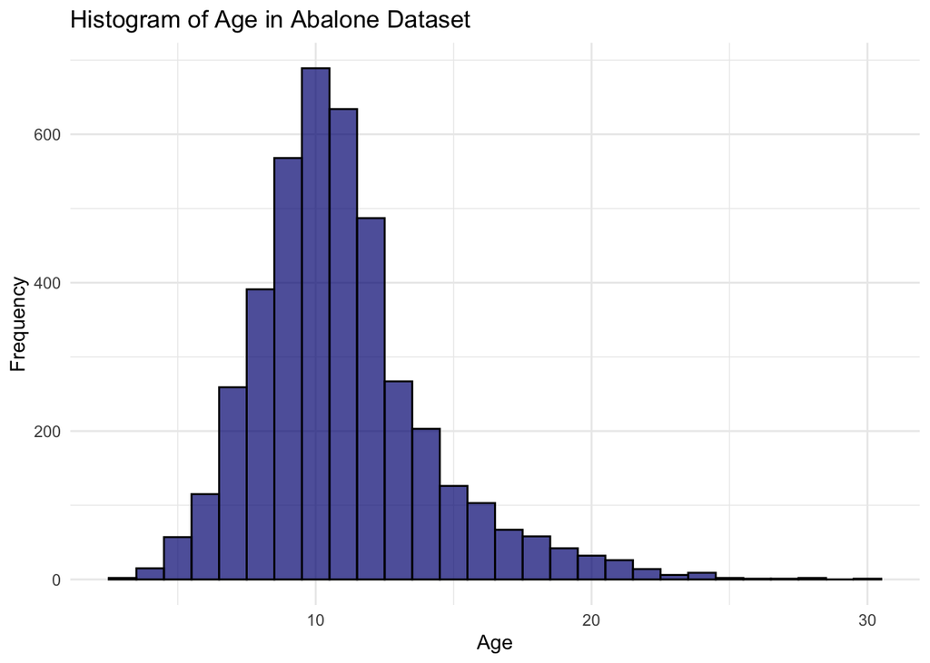

```r
# Create a histogram of age
ggplot(abalone, aes(x = age)) +
  geom_histogram(binwidth = 1, fill = "navy", color = "black", alpha = 0.7) +
  labs(x = "Age", y = "Frequency", title = "Histogram of Age in Abalone Dataset") +
  theme_minimal()
```

> The histogram above shows that the age variable is unimodal and right-skewed. It’s not completely clear though so we can assess skewness by comparing the mean and median as a test. The test below confirms that it is right-skewed.

```r
# Print mean value
print(paste("Mean:", mean(abalone$age)))
```

```
[1] "Mean: 11.4336844625329"
```

```r
# Print median value
print(paste("Median:", median(abalone$age)))
```

```
[1] "Median: 10.5"
```

### Question 2

Split the abalone data into a training set and a testing set. Use stratified sampling. You should decide on appropriate percentages for splitting the data.

*Remember that you’ll need to set a seed at the beginning of the document to reproduce your results.*

> First, we’ll need to figure out which variable to stratify by.

[figure not shown]

```r
# Reformat variables as characters for processing then reeshape the data to long format
abalone_long <- abalone %>%
  mutate(across(everything(), as.character)) %>%
  pivot_longer(cols = everything(), names_to = "Variable", values_to = "Value")

# Create facet histogram plots with a conditional check for numeric and categorical variables
ggplot(abalone_long, aes(x = Value)) +
  # Filter variables for numeric data types for plotting
  geom_histogram(data = subset(abalone_long, sapply(Value, is.numeric)),
                 fill = "navy", color = "black") +
  # Filter variables for categorical data types for plotting
  geom_bar(data = subset(abalone_long, !sapply(Value, is.numeric)),
           fill = "navy", color = "black") +
  facet_wrap(~ Variable, scales = "free") +
  labs(title = "Histograms/Bar Charts of Variables in Abalone Dataset",
       x = "Value", y = "Frequency") +
  theme_minimal()
```

```r
# Set seed for reproducibility purposes
set.seed(123)

# Split the data with stratified sampling
split <- initial_split(abalone, prop = 0.75, strata = age)

# Subset training set
abalone_train <- training(split)

# Subset testing set
abalone_test <- testing(split)
```

### Question 3

Using the **training** data, create a recipe predicting the outcome variable, `age`, with all other predictor variables. Note that you **should not** include `rings` to predict `age`. *Explain why you shouldn’t use `rings` to predict `age`.*

Steps for your recipe:

1. dummy code any categorical predictors
2. create interactions between
   - `type` and `shucked_weight`,
   - `longest_shell` and `diameter`,
   - `shucked_weight` and `shell_weight`
3. center all predictors, and
4. scale all predictors.

You’ll need to investigate the `tidymodels` documentation to find the appropriate step functions to use.

```r
# Create the recipe
recipe_age <- recipe(age ~ ., data = abalone_train) %>%
  step_rm(rings) %>%  # Remove the `rings` variable
  step_interact(  # Create interactions
    terms = ~ type:shucked_weight +
             longest_shell:diameter +
             shucked_weight:shell_weight
  ) %>%
  step_dummy(all_nominal(), -all_outcomes()) %>%  # Dummy code categorical predictors
  step_center(all_predictors()) %>%  # Center all predictors
  step_scale(all_predictors())       # Scale all predictors
```

> Rings should not be included to predict age because age was created as a function of rings. It does not represent collected data and will skew the results.

### Question 4

Create and store a linear regression object using the `"lm"` engine.

```r
# Define a linear regression model using the "lm" engine
linear_mod <- linear_reg() %>%
  set_engine("lm")
```

### Question 5

Create and store a KNN object using the `"kknn"` engine. Specify `k = 7`.

```r
# Define a KNN model with k = 7 using the "kknn" engine
knn_mod <- nearest_neighbor(neighbors = 7) %>%
  set_engine("kknn") %>%
  set_mode("regression")
```

### Question 6

Now, for each of these models (linear regression and KNN):

1. set up an empty workflow,
2. add the model, and
3. add the recipe that you created in Question 3.

Note that you should be setting up two separate workflows.

Fit both models to the training set.

> Linear Regression Model

```r
# Set up workflow for Linear Regression
lm_workflow <- workflow() %>%
  add_model(linear_mod) %>%
  add_recipe(recipe_age)

# Fit the lm workflow to the training data
lm_workflow_fit <- lm_workflow %>%
  fit(data = abalone_train)
```

> KNN Model

```r
# Set up workflow for Linear Regression
knn_workflow <- workflow() %>%
  add_model(knn_mod) %>%
  add_recipe(recipe_age)


# Fit the knn workflow to the training data
knn_workflow_fit <- knn_workflow %>%
  fit(data = abalone_train)
```

### Question 7

Use your linear regression `fit()` object to predict the age of a hypothetical female abalone with longest_shell = 0.50, diameter = 0.10, height = 0.30, whole_weight = 4, shucked_weight = 1, viscera_weight = 2, and shell_weight = 1.

```r
# Create a new data frame with the hypothetical abalone values
new_individual <- tibble(
  type = factor("F", levels = c("F", "I", "M")),
  longest_shell = 0.50,
  diameter = 0.10,
  height = 0.30,
  whole_weight = 4,
  shucked_weight = 1,
  viscera_weight = 2,
  shell_weight = 1,
  rings = NA
)

# Use the lm_workflow_fit to predict age for the new data
predicted_age <- predict(lm_workflow_fit, new_individual)

# Print the predicted age as a gt table
predicted_age %>%
  gt() %>%
  cols_label(.pred = "Predicted Age")
```

| Predicted Age |
| --- |
| 22.98725 |

### Question 8

Now you want to assess your models’ performance. To do this, use the `yardstick` package:

1. Create a metric set that includes *R<sup>2</sup>*, RMSE (root mean squared error), and MAE (mean absolute error).
2. Use `augment()` to create a tibble of your model’s predicted values from the **testing data** along with the actual observed ages (these are needed to assess your model’s performance).
3. Finally, apply your metric set to the tibble, report the results, and interpret the *R^2* value.

Repeat these steps once for the linear regression model and for the KNN model.

> Linear Regression:

> According to the results below, the linear model results in an RMSE of 2.21 and MAE of 1.55. The R^2 value is 0.54, which means that this linear model explain 54% of the variance in the testing data.

```r
# Create a metric set object that includes R2, RMSE, MAE
lm_metric_set <- metric_set(rsq, rmse, mae)

# Create dataframe of model predictions on test data
lm_predicted_data <- augment(lm_workflow_fit, new_data = abalone_test)

# Collect performance metrics from model
lm_metrics <- lm_predicted_data %>%
  metrics(truth = age, estimate = .pred)

# Print metrics
lm_metrics %>%
  gt()
```

| .metric | .estimator | .estimate |
| --- | --- | --- |
| rmse | standard | 2.2139394 |
| rsq | standard | 0.5388249 |
| mae | standard | 1.5541276 |

> KNN Model

```r
# Create a metric set object that includes R2, RMSE, MAE
knn_metric_set <- metric_set(rsq, rmse, mae)

# Create dataframe of model predictions on test data
knn_predicted_data <- augment(knn_workflow_fit, new_data = abalone_test)

# Collect performance metrics from model
knn_metrics <- knn_predicted_data %>%
  metrics(truth = age, estimate = .pred)

# Print metrics
knn_metrics %>%
  gt()
```

| .metric | .estimator | .estimate |
| --- | --- | --- |
| rmse | standard | 2.3486267 |
| rsq | standard | 0.4836806 |
| mae | standard | 1.6164785 |

### Question 9

Which model performed better on the testing data? Explain why you think this might be. Are you surprised by any of your results? Why or why not?

> Based on the results above, the linear model outperforms the KNN model on the abalone_test data. We know this because the linear model has a lower RMSE, higher R2, and lower MAE. A lower RMSE means that the linear model performed better at minimizing squared errors. A higher R2 means that the linear model explained more of the variance in the testing data. Finally, a lower MAE means that the linear model predicts were closer to the true values on average. The linear model may have performed better than the knn model because there’s a linear relationship between the features and the target variable. The difference in performance between the two models is not significant however. Knn may perform better if we chose a different number of clusters (or K value).